# Initial Setup

This Jupyter Notebook was successfully run in Google Colab, and input files are located in my personal google drive as well as in files submitted along with. This jupyter notebook uses the files in my google drive. Please change the path accordingly to run.

### *Note:*

Google Colab has been used to do this assignment due to lack of a personal GPU machine with CUDA.

```python
from google.colab import drive
drive.mount('/content/drive')
```

> Importing Libraries and setting path for necessary files.

```python
from __future__ import print_function
import torch
import torch.nn as nn
import torch.nn.functional as F
import torch.optim as optim
from torchvision import datasets, transforms
import matplotlib.pyplot as plt
import pdb
import numpy as np
import pandas as pd
import os

path='drive/My Drive/computer_vision/assignment_02/'
incsv_path=path+'SIVARAMT@TCD.IE_in.csv'
netcsv_path=path+'SIVARAMT@TCD.IE_network.csv'
sigma_path=path+'SIVARAMT@TCD.IE_sigma.csv'
dncnn_path=path+'DnCNN/'
img_path=path+'SIVARAMT@TCD.IE_007.png'
```

# MNIST classification (20 marks)

## You are provided with code mnist.py that trains a Convolutional Neural Network on MNIST dataset. You are required to modify this file.

### a) In the file mnist.py identify where the Stochastic Gradient Descent optimizer is created. Train the default CNN architecture by choosing appropriate parameter values for:

i) Learning rate – explain what happens when you use too large or too small value and explain why it is happening.

ii) Weight decay – explain what happens when you use too large or too small regularization and explain why it is happening.

> i) Learning rate – explain what happens when you use too large or too small value and explain why it is happening

Learning rate determines how fast or slow the convergence should be. It influences the amount that the weights are updated. Large values of learning rate means large change in weights. It shouldn’t be too large as we may end up diverging and training becomes unstable. It shouldn’t be too small as we may take way longer time (a lot of epochs) in converging and sometimes doesn’t converge.

Learning rate around 0.1 or more led to an accuracy around 10% or less. On trying different values it was found that Learning Rate as 0.01 produced the best accuracy being 98%.

> ii) Weight decay – explain what happens when you use too large or too small regularization and explain why it is happening.

Weight Decay helps in how fast or slow the weight decays to zero. Weight decay helps in generalising and helps tackle overfitting by penalising weight, by subtracting `weight_decay x weight` from `weight`. The problem with this being too high is it might make our model underfit. If it is too small we might have to stop the training earlier. One of the benefits with weight decay/weight regularisation is it helps us tackle what is known as *exploding gradient problem*, where gradients accumulate leading to large values which makes the network unstable and weights end up becoming so large.

Weight Decay around 0.1 or more with Learning Rate equal to 0.01, led to an accuracy around 96%. On trying different values it was found that Weight Decay as 0.001 produced the best accuracy being 98%.

More changes led to an accuracy of 98% with a learning rate of 0.01 and a weight decay of 0.001

We can see the results with an Average Loss of 0.0523 and an Accuracy of 9834/10000 (98%)

```python
# Training hyperparameters
epochs = 1
batch_size = 16
learning_rate = 0.01 # TODO
momentum = 0.9
weight_decay = 0.001 # TODO
log_interval = 20
```

```python
class CNN(nn.Module):
    def __init__(self):
        super(CNN, self).__init__()
        self.conv1 = nn.Conv2d(in_channels=1, out_channels=16,
                               kernel_size=5, stride=1, padding=0)
        self.maxpool = nn.MaxPool2d(2)
        self.conv2 = nn.Conv2d(in_channels=16, out_channels=32,
                               kernel_size=3, stride=1, padding=0)
        self.fc1 = nn.Linear(in_features=800, out_features=128)
        self.fc2 = nn.Linear(in_features=128, out_features=10)

        nn.init.kaiming_normal_(self.conv1.weight, nonlinearity='relu')
        nn.init.kaiming_normal_(self.conv2.weight, nonlinearity='relu')
        nn.init.kaiming_normal_(self.fc1.weight, nonlinearity='relu')
        nn.init.kaiming_normal_(self.fc2.weight, nonlinearity='linear')

    def forward(self, x):
        x = self.conv1(x)
        x = F.relu(x)
        x = self.maxpool(x)
        x = self.conv2(x)
        x = F.relu(x)
        x = self.maxpool(x)
        x = x.view(-1, 800)
        x = self.fc1(x)
        x = F.relu(x)
        x = self.fc2(x)
        return F.log_softmax(x, dim=1)

class CNN2(nn.Module):
    def __init__(self):
        super(CNN2, self).__init__()
        self.conv1 = nn.Conv2d(in_channels=1, out_channels=32,
                               kernel_size=5, stride=1, padding=0)
        self.maxpool = nn.MaxPool2d(2)
        self.conv2 = nn.Conv2d(in_channels=32, out_channels=64,
                               kernel_size=5, stride=1, padding=0)
        self.fc1 = nn.Linear(in_features=1024, out_features=256)
        self.fc2 = nn.Linear(in_features=256, out_features=10)

        nn.init.kaiming_normal_(self.conv1.weight, nonlinearity='relu')
        nn.init.kaiming_normal_(self.conv2.weight, nonlinearity='relu')
        nn.init.kaiming_normal_(self.fc1.weight, nonlinearity='relu')
        nn.init.kaiming_normal_(self.fc2.weight, nonlinearity='linear')

    def forward(self, x):
        x = self.conv1(x)
        x = F.relu(x)
        x = self.maxpool(x)
        x = self.conv2(x)
        x = F.relu(x)
        x = self.maxpool(x)
        # print(x.shape)
        x = x.view(-1, 1024)
        # print(x.shape)
        x = self.fc1(x)
        x = F.relu(x)
        x = self.fc2(x)
        return F.log_softmax(x, dim=1)

class CNN3(nn.Module):
    def __init__(self):
        super(CNN3, self).__init__()
        self.conv1 = nn.Conv2d(in_channels=1, out_channels=32,
                               kernel_size=5, stride=1, padding=0)
        self.maxpool = nn.MaxPool2d(2)
        self.conv2 = nn.Conv2d(in_channels=32, out_channels=64,
                               kernel_size=5, stride=1, padding=0)
        self.fc1 = nn.Linear(in_features=1024, out_features=256)
        self.dropout = nn.Dropout(0.2)
        self.fc2 = nn.Linear(in_features=256, out_features=10)
        self.dropout = nn.Dropout(0.2)

        nn.init.kaiming_normal_(self.conv1.weight, nonlinearity='leaky_relu')
        nn.init.kaiming_normal_(self.conv2.weight, nonlinearity='leaky_relu')
        nn.init.kaiming_normal_(self.fc1.weight, nonlinearity='leaky_relu')
        nn.init.kaiming_normal_(self.fc2.weight, nonlinearity='linear')
        # TODO

    def forward(self, x):
        x = self.conv1(x)
        x = F.relu(x)
        x = self.maxpool(x)
        x = self.conv2(x)
        x = F.relu(x)
        x = self.maxpool(x)
        # print(x.shape)
        x = x.view(-1, 1024)
        # print(x.shape)
        x = self.fc1(x)
        x = F.relu(x)
        x = self.fc2(x)
        return F.log_softmax(x, dim=1)

        # def __init__(self):
        # super(mnist_model, self).__init__()
        # self.feats = nn.Sequential(
        #     nn.Conv2d(1, 32, 3, 1, 1),
        #     nn.MaxPool2d(2, 2),
        #     nn.ReLU(True),
        #     nn.BatchNorm2d(32),

        #     nn.Conv2d(32, 64, 3,  1, 1),
        #     nn.ReLU(True),
        #     nn.BatchNorm2d(64),

        #     nn.Conv2d(64, 64, 3,  1, 1),
        #     nn.MaxPool2d(2, 2),
        #     nn.ReLU(True),
        #     nn.BatchNorm2d(64),

        #     nn.Conv2d(64, 128, 3, 1, 1),
        #     nn.ReLU(True),
        #     nn.BatchNorm2d(128)
        # )

        # self.classifier = nn.Conv2d(128, 10, 1)
        # self.avgpool = nn.AvgPool2d(6, 6)
        # self.dropout = nn.Dropout(0.5)
```

```python
def plot_data(data, label, text):
    fig = plt.figure()
    for i in range(6):
        plt.subplot(2,3,i+1)
        plt.tight_layout()
        plt.imshow(data[i][0], cmap='gray', interpolation='none')
        plt.title(text + ": {}".format(label[i]))
        plt.xticks([])
        plt.yticks([])
    plt.show()
```

```python
def predict_batch(model, device, test_loader):
    examples = enumerate(test_loader)
    model.eval()
    with torch.no_grad():
        batch_idx, (data, target) = next(examples)
        data, target = data.to(device), target.to(device)
        output = model(data)
        pred = output.cpu().data.max(1, keepdim=True)[1] # get the index of the max log-probability
        pred = pred.numpy()
    return data.cpu().data.numpy(), target.cpu().data.numpy(), pred
```

```python
def plot_graph(train_x, train_y, test_x, test_y, ylabel=''):
    fig = plt.figure()
    plt.plot(train_x, train_y, color='blue')
    plt.plot(test_x, test_y, color='red')
    plt.legend(['Train', 'Test'], loc='upper right')
    plt.xlabel('number of training examples seen')
    plt.ylabel(ylabel)
    plt.grid()
    plt.show()
```

```python
def train(model, device, train_loader, optimizer, epoch, losses=[], counter=[], errors=[]):
    model.train()
    correct=0
    for batch_idx, (data, target) in enumerate(train_loader):
        data, target = data.to(device), target.to(device)
        optimizer.zero_grad()
        output = model(data)
        loss = F.nll_loss(output, target)
        loss.backward()
        optimizer.step()
        if batch_idx % log_interval == 0:
            print('Train Epoch: {} [{}/{} ({:.0f}%)]\tLoss: {:.6f}'.format(
                epoch, batch_idx * len(data), len(train_loader.dataset),
                100. * batch_idx / len(train_loader), loss.item()))
            losses.append(loss.item())
            counter.append((batch_idx*batch_size) + ((epoch-1)*len(train_loader.dataset)))
        pred = output.max(1, keepdim=True)[1]
        correct += pred.eq(target.view_as(pred)).sum().item()
    errors.append(100. * (1 - correct / len(train_loader.dataset)))
```

```python
def test(model, device, test_loader, losses=[], errors=[]):
    model.eval()
    test_loss = 0
    correct = 0
    with torch.no_grad():
        for data, target in test_loader:
            data, target = data.to(device), target.to(device)
            output = model(data)
            test_loss += F.nll_loss(output, target, reduction='sum').item() # sum up batch loss
            pred = output.max(1, keepdim=True)[1] # get the index of the max log-probability
            correct += pred.eq(target.view_as(pred)).sum().item()

    test_loss /= len(test_loader.dataset)
    print('\nTest set: Average loss: {:.4f}, Accuracy: {}/{} ({:.0f}%)\n'.format(
        test_loss, correct, len(test_loader.dataset),
        100. * correct / len(test_loader.dataset)))
    losses.append(test_loss)
    errors.append(100. *  (1 - correct / len(test_loader.dataset)))
```

> MNIST with default CNN architectre called using `CNN()` function.

```
0it [00:00, ?it/s]
```

```
Downloading http://yann.lecun.com/exdb/mnist/train-images-idx3-ubyte.gz to ../data/MNIST/raw/train-images-idx3-ubyte.gz
```

```
9920512it [00:01, 9394496.41it/s]
```

```
Extracting ../data/MNIST/raw/train-images-idx3-ubyte.gz to ../data/MNIST/raw
```

```
Downloading http://yann.lecun.com/exdb/mnist/train-labels-idx1-ubyte.gz to ../data/MNIST/raw/train-labels-idx1-ubyte.gz
```

```
32768it [00:00, 140132.15it/s]
```

```
Extracting ../data/MNIST/raw/train-labels-idx1-ubyte.gz to ../data/MNIST/raw
Downloading http://yann.lecun.com/exdb/mnist/t10k-images-idx3-ubyte.gz to ../data/MNIST/raw/t10k-images-idx3-ubyte.gz
```

```
1654784it [00:00, 2346848.10it/s]
0it [00:00, ?it/s]
```

```
Extracting ../data/MNIST/raw/t10k-images-idx3-ubyte.gz to ../data/MNIST/raw
Downloading http://yann.lecun.com/exdb/mnist/t10k-labels-idx1-ubyte.gz to ../data/MNIST/raw/t10k-labels-idx1-ubyte.gz
```

```
8192it [00:00, 52380.28it/s]
```

```
Extracting ../data/MNIST/raw/t10k-labels-idx1-ubyte.gz to ../data/MNIST/raw
Processing...
Done!

Test set: Average loss: 3.7300, Accuracy: 1126/10000 (11%)

Train Epoch: 1 [0/60000 (0%)]	Loss: 4.166334
Train Epoch: 1 [320/60000 (1%)]	Loss: 1.679391
Train Epoch: 1 [640/60000 (1%)]	Loss: 0.622721
Train Epoch: 1 [960/60000 (2%)]	Loss: 0.472928
Train Epoch: 1 [1280/60000 (2%)]	Loss: 0.273914
Train Epoch: 1 [1600/60000 (3%)]	Loss: 0.282375
Train Epoch: 1 [1920/60000 (3%)]	Loss: 0.317651
Train Epoch: 1 [2240/60000 (4%)]	Loss: 0.294279
Train Epoch: 1 [2560/60000 (4%)]	Loss: 0.291713
Train Epoch: 1 [2880/60000 (5%)]	Loss: 0.102048
Train Epoch: 1 [3200/60000 (5%)]	Loss: 0.132458
Train Epoch: 1 [3520/60000 (6%)]	Loss: 0.005501
Train Epoch: 1 [3840/60000 (6%)]	Loss: 0.025713
Train Epoch: 1 [4160/60000 (7%)]	Loss: 0.038480
Train Epoch: 1 [4480/60000 (7%)]	Loss: 0.022356
Train Epoch: 1 [4800/60000 (8%)]	Loss: 0.096958
Train Epoch: 1 [5120/60000 (9%)]	Loss: 0.117514
Train Epoch: 1 [5440/60000 (9%)]	Loss: 0.284591
Train Epoch: 1 [5760/60000 (10%)]	Loss: 0.025939
Train Epoch: 1 [6080/60000 (10%)]	Loss: 0.015547
Train Epoch: 1 [6400/60000 (11%)]	Loss: 0.240410
Train Epoch: 1 [6720/60000 (11%)]	Loss: 0.076901
Train Epoch: 1 [7040/60000 (12%)]	Loss: 0.007340
Train Epoch: 1 [7360/60000 (12%)]	Loss: 0.063892
Train Epoch: 1 [7680/60000 (13%)]	Loss: 0.147861
Train Epoch: 1 [8000/60000 (13%)]	Loss: 0.452311
Train Epoch: 1 [8320/60000 (14%)]	Loss: 0.056653
Train Epoch: 1 [8640/60000 (14%)]	Loss: 0.015125
Train Epoch: 1 [8960/60000 (15%)]	Loss: 0.010631
Train Epoch: 1 [9280/60000 (15%)]	Loss: 0.013825
Train Epoch: 1 [9600/60000 (16%)]	Loss: 0.053177
Train Epoch: 1 [9920/60000 (17%)]	Loss: 0.439326
Train Epoch: 1 [10240/60000 (17%)]	Loss: 0.155915
Train Epoch: 1 [10560/60000 (18%)]	Loss: 0.025239
```

[output cut: 141 more lines]

```
Train Epoch: 1 [56000/60000 (93%)]	Loss: 0.085695
Train Epoch: 1 [56320/60000 (94%)]	Loss: 0.055928
Train Epoch: 1 [56640/60000 (94%)]	Loss: 0.047024
Train Epoch: 1 [56960/60000 (95%)]	Loss: 0.019327
Train Epoch: 1 [57280/60000 (95%)]	Loss: 0.004119
Train Epoch: 1 [57600/60000 (96%)]	Loss: 0.039459
Train Epoch: 1 [57920/60000 (97%)]	Loss: 0.193636
Train Epoch: 1 [58240/60000 (97%)]	Loss: 0.032656
Train Epoch: 1 [58560/60000 (98%)]	Loss: 0.003984
Train Epoch: 1 [58880/60000 (98%)]	Loss: 0.188853
Train Epoch: 1 [59200/60000 (99%)]	Loss: 0.346788
Train Epoch: 1 [59520/60000 (99%)]	Loss: 0.005258
Train Epoch: 1 [59840/60000 (100%)]	Loss: 0.209936

Test set: Average loss: 0.0523, Accuracy: 9834/10000 (98%)
```

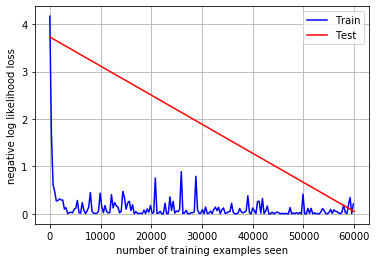

[figure not shown]

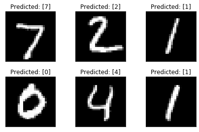

```python
def main():
    use_cuda = torch.cuda.is_available()
    device = torch.device("cuda" if use_cuda else "cpu")

    # data transformation
    train_data = datasets.MNIST('../data', train=True, download=True,
                   transform=transforms.Compose([
                       transforms.ToTensor(),
                       transforms.Normalize((0.1307,), (0.3081,))
                   ]))
    test_data = datasets.MNIST('../data', train=False,
                   transform=transforms.Compose([
                       transforms.ToTensor(),
                       transforms.Normalize((0.1307,), (0.3081,))
                   ]))
        # data loaders
    kwargs = {'num_workers': 1, 'pin_memory': True} if use_cuda else {}
    train_loader = torch.utils.data.DataLoader(train_data, batch_size=batch_size, shuffle=True, **kwargs)
    test_loader = torch.utils.data.DataLoader(test_data, batch_size=batch_size, shuffle=False, **kwargs)

	# extract and plot random samples of data
    #examples = enumerate(test_loader)
    #batch_idx, (data, target) = next(examples)
    #plot_data(data, target, 'Ground truth')


        # model creation
    model = CNN().to(device)
    # optimizer creation
    optimizer = optim.SGD(model.parameters(), lr=learning_rate, momentum=momentum, weight_decay=weight_decay)

    # lists for saving history
    train_losses = []
    train_counter = []
    test_losses = []
    test_counter = [i*len(train_loader.dataset) for i in range(epochs + 1)]
    train_errors = []
    test_errors = []
    error_counter = [i*len(train_loader.dataset) for i in range(epochs)]

        # test of randomly initialized model
    test(model, device, test_loader, losses=test_losses)

    # global training and testing loop
    for epoch in range(1, epochs + 1):
        train(model, device, train_loader, optimizer, epoch, losses=train_losses, counter=train_counter, errors=train_errors)
        test(model, device, test_loader, losses=test_losses, errors=test_errors)

            # plotting training history
    plot_graph(train_counter, train_losses, test_counter, test_losses, ylabel='negative log likelihood loss')
    plot_graph(error_counter, train_errors, error_counter, test_errors, ylabel='error (%)')

    # extract and plot random samples of data with predicted labels
    data, _, pred = predict_batch(model, device, test_loader)
    plot_data(data, pred, 'Predicted')

if __name__ == '__main__':
    main()
```

B- Correct the mistakes in CNN2 and train it on MNIST train set. Desired architecture of CNN2 is displayed on given diagam, CONV KxK, N represents N features extracted by KxK filters, FC N represent fully-connected layer with N nodes. Set the padding so each convolution preserves input feature size.

> MNIST with desired CNN architectre given in the diagram called using `CNN2()` function.

```
Test set: Average loss: 3.9323, Accuracy: 1222/10000 (12%)

Train Epoch: 1 [0/60000 (0%)]	Loss: 3.837185
Train Epoch: 1 [320/60000 (1%)]	Loss: 1.394982
Train Epoch: 1 [640/60000 (1%)]	Loss: 0.669273
Train Epoch: 1 [960/60000 (2%)]	Loss: 0.260893
Train Epoch: 1 [1280/60000 (2%)]	Loss: 0.474508
Train Epoch: 1 [1600/60000 (3%)]	Loss: 0.055878
Train Epoch: 1 [1920/60000 (3%)]	Loss: 0.478752
Train Epoch: 1 [2240/60000 (4%)]	Loss: 0.191858
Train Epoch: 1 [2560/60000 (4%)]	Loss: 0.779618
Train Epoch: 1 [2880/60000 (5%)]	Loss: 0.267939
Train Epoch: 1 [3200/60000 (5%)]	Loss: 0.016607
Train Epoch: 1 [3520/60000 (6%)]	Loss: 0.104650
Train Epoch: 1 [3840/60000 (6%)]	Loss: 0.527472
Train Epoch: 1 [4160/60000 (7%)]	Loss: 0.050110
Train Epoch: 1 [4480/60000 (7%)]	Loss: 0.425755
Train Epoch: 1 [4800/60000 (8%)]	Loss: 0.097411
Train Epoch: 1 [5120/60000 (9%)]	Loss: 0.599391
Train Epoch: 1 [5440/60000 (9%)]	Loss: 0.130231
Train Epoch: 1 [5760/60000 (10%)]	Loss: 0.070327
Train Epoch: 1 [6080/60000 (10%)]	Loss: 0.413909
Train Epoch: 1 [6400/60000 (11%)]	Loss: 0.096563
Train Epoch: 1 [6720/60000 (11%)]	Loss: 0.040917
Train Epoch: 1 [7040/60000 (12%)]	Loss: 0.272166
Train Epoch: 1 [7360/60000 (12%)]	Loss: 0.217423
Train Epoch: 1 [7680/60000 (13%)]	Loss: 0.061349
Train Epoch: 1 [8000/60000 (13%)]	Loss: 0.019114
Train Epoch: 1 [8320/60000 (14%)]	Loss: 0.291199
Train Epoch: 1 [8640/60000 (14%)]	Loss: 0.203096
Train Epoch: 1 [8960/60000 (15%)]	Loss: 0.050179
Train Epoch: 1 [9280/60000 (15%)]	Loss: 0.003871
Train Epoch: 1 [9600/60000 (16%)]	Loss: 0.066975
Train Epoch: 1 [9920/60000 (17%)]	Loss: 0.025995
Train Epoch: 1 [10240/60000 (17%)]	Loss: 0.088872
Train Epoch: 1 [10560/60000 (18%)]	Loss: 0.011290
Train Epoch: 1 [10880/60000 (18%)]	Loss: 0.132143
Train Epoch: 1 [11200/60000 (19%)]	Loss: 0.017998
Train Epoch: 1 [11520/60000 (19%)]	Loss: 0.007733
Train Epoch: 1 [11840/60000 (20%)]	Loss: 0.078252
```

[output cut: 137 more lines]

```
Train Epoch: 1 [56000/60000 (93%)]	Loss: 0.034538
Train Epoch: 1 [56320/60000 (94%)]	Loss: 0.013853
Train Epoch: 1 [56640/60000 (94%)]	Loss: 0.396049
Train Epoch: 1 [56960/60000 (95%)]	Loss: 0.000438
Train Epoch: 1 [57280/60000 (95%)]	Loss: 0.006332
Train Epoch: 1 [57600/60000 (96%)]	Loss: 0.003782
Train Epoch: 1 [57920/60000 (97%)]	Loss: 0.002432
Train Epoch: 1 [58240/60000 (97%)]	Loss: 0.004464
Train Epoch: 1 [58560/60000 (98%)]	Loss: 0.011280
Train Epoch: 1 [58880/60000 (98%)]	Loss: 0.024532
Train Epoch: 1 [59200/60000 (99%)]	Loss: 0.011300
Train Epoch: 1 [59520/60000 (99%)]	Loss: 0.009238
Train Epoch: 1 [59840/60000 (100%)]	Loss: 0.019783

Test set: Average loss: 0.0477, Accuracy: 9847/10000 (98%)
```

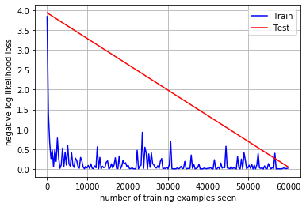

[figure not shown]

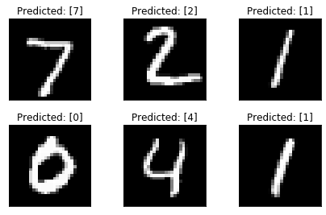

```python
def main():
    use_cuda = torch.cuda.is_available()
    device = torch.device("cuda" if use_cuda else "cpu")

    # data transformation
    train_data = datasets.MNIST('../data', train=True, download=True,
                   transform=transforms.Compose([
                       transforms.ToTensor(),
                       transforms.Normalize((0.1307,), (0.3081,))
                   ]))
    test_data = datasets.MNIST('../data', train=False,
                   transform=transforms.Compose([
                       transforms.ToTensor(),
                       transforms.Normalize((0.1307,), (0.3081,))
                   ]))
        # data loaders
    kwargs = {'num_workers': 1, 'pin_memory': True} if use_cuda else {}
    train_loader = torch.utils.data.DataLoader(train_data, batch_size=batch_size, shuffle=True, **kwargs)
    test_loader = torch.utils.data.DataLoader(test_data, batch_size=batch_size, shuffle=False, **kwargs)

	# extract and plot random samples of data
    #examples = enumerate(test_loader)
    #batch_idx, (data, target) = next(examples)
    #plot_data(data, target, 'Ground truth')


        # model creation
    model = CNN2().to(device)
    # optimizer creation
    optimizer = optim.SGD(model.parameters(), lr=learning_rate, momentum=momentum, weight_decay=weight_decay)

    # lists for saving history
    train_losses = []
    train_counter = []
    test_losses = []
    test_counter = [i*len(train_loader.dataset) for i in range(epochs + 1)]
    train_errors = []
    test_errors = []
    error_counter = [i*len(train_loader.dataset) for i in range(epochs)]

        # test of randomly initialized model
    test(model, device, test_loader, losses=test_losses)

    # global training and testing loop
    for epoch in range(1, epochs + 1):
        train(model, device, train_loader, optimizer, epoch, losses=train_losses, counter=train_counter, errors=train_errors)
        test(model, device, test_loader, losses=test_losses, errors=test_errors)

            # plotting training history
    plot_graph(train_counter, train_losses, test_counter, test_losses, ylabel='negative log likelihood loss')
    plot_graph(error_counter, train_errors, error_counter, test_errors, ylabel='error (%)')

    # extract and plot random samples of data with predicted labels
    data, _, pred = predict_batch(model, device, test_loader)
    plot_data(data, pred, 'Predicted')

if __name__ == '__main__':
    main()
```

C- Change dataset to fashion MNIST (https://research.zalando.com/welcome/mission/research- projects/fashion-mnist/, hint: take a look at torchvision.datasets), estimate the dataset mean and standard deviation and use it to normalize the data in the data loader.

> Function that calculates mean and standard deviation which is used for normalising. The mean and standard deviation are used *in the next cell* by calling this function, where the dataset is also changed to Fasion-MNIST as asked.

```python
  # def mean_std_func(loader, train_data):
  #   ## Calculating Mean
  #   mean=np.zeros((28,28))
  #   for i in range(60000):
  #     temp=train_data[i][0][0].numpy()
  #     mean=mean+temp
  #   mean=mean/60000
  #   mean2=np.sum(mean)/784
  #   ## Calculating Standard Deviation
  #   mean = 0.0
  #   for images, _ in loader:
  #     batch_samples = images.size(0)
  #     images = images.view(batch_samples, images.size(1), -1)
  #     mean += images.mean(2).sum(0)
  #   mean = mean / len(loader.dataset)
  #   var=0
  #   for images, _ in loader:
  #     batch_samples = images.size(0)
  #     images = images.view(batch_samples, images.size(1), -1)
  #     var += ((images - mean.unsqueeze(1))**2).sum([0,2])
  #   std = torch.sqrt(var / (len(loader.dataset)*224*224))
  #   std=std.numpy()[0]*10
  #   return mean2,std


def mean_std_func(loader):
  samples = enumerate(loader)
  _, (loader_data, _) = next(samples)
  mean = loader_data.mean()
  stddev = loader_data.std()
  return mean, stddev
```

```
Test set: Average loss: 3.3309, Accuracy: 1351/10000 (14%)

Train Epoch: 1 [0/60000 (0%)]	Loss: 3.020317
Train Epoch: 1 [320/60000 (1%)]	Loss: 1.059000
Train Epoch: 1 [640/60000 (1%)]	Loss: 0.996584
Train Epoch: 1 [960/60000 (2%)]	Loss: 0.813563
Train Epoch: 1 [1280/60000 (2%)]	Loss: 0.731026
Train Epoch: 1 [1600/60000 (3%)]	Loss: 1.279112
Train Epoch: 1 [1920/60000 (3%)]	Loss: 0.769869
Train Epoch: 1 [2240/60000 (4%)]	Loss: 1.235133
Train Epoch: 1 [2560/60000 (4%)]	Loss: 0.718465
Train Epoch: 1 [2880/60000 (5%)]	Loss: 0.441030
Train Epoch: 1 [3200/60000 (5%)]	Loss: 0.360971
Train Epoch: 1 [3520/60000 (6%)]	Loss: 0.483445
Train Epoch: 1 [3840/60000 (6%)]	Loss: 0.718705
Train Epoch: 1 [4160/60000 (7%)]	Loss: 0.249558
Train Epoch: 1 [4480/60000 (7%)]	Loss: 0.576680
Train Epoch: 1 [4800/60000 (8%)]	Loss: 0.558668
Train Epoch: 1 [5120/60000 (9%)]	Loss: 0.438551
Train Epoch: 1 [5440/60000 (9%)]	Loss: 0.673116
Train Epoch: 1 [5760/60000 (10%)]	Loss: 0.562719
Train Epoch: 1 [6080/60000 (10%)]	Loss: 0.364088
Train Epoch: 1 [6400/60000 (11%)]	Loss: 0.355715
Train Epoch: 1 [6720/60000 (11%)]	Loss: 0.893765
Train Epoch: 1 [7040/60000 (12%)]	Loss: 0.371969
Train Epoch: 1 [7360/60000 (12%)]	Loss: 0.368129
Train Epoch: 1 [7680/60000 (13%)]	Loss: 1.168782
Train Epoch: 1 [8000/60000 (13%)]	Loss: 0.612358
Train Epoch: 1 [8320/60000 (14%)]	Loss: 0.420234
Train Epoch: 1 [8640/60000 (14%)]	Loss: 0.530779
Train Epoch: 1 [8960/60000 (15%)]	Loss: 0.839251
Train Epoch: 1 [9280/60000 (15%)]	Loss: 0.601115
Train Epoch: 1 [9600/60000 (16%)]	Loss: 0.565594
Train Epoch: 1 [9920/60000 (17%)]	Loss: 1.334176
Train Epoch: 1 [10240/60000 (17%)]	Loss: 0.409197
Train Epoch: 1 [10560/60000 (18%)]	Loss: 0.382335
Train Epoch: 1 [10880/60000 (18%)]	Loss: 0.209185
Train Epoch: 1 [11200/60000 (19%)]	Loss: 0.365397
Train Epoch: 1 [11520/60000 (19%)]	Loss: 0.707421
Train Epoch: 1 [11840/60000 (20%)]	Loss: 0.917584
```

[output cut: 137 more lines]

```
Train Epoch: 1 [56000/60000 (93%)]	Loss: 0.304529
Train Epoch: 1 [56320/60000 (94%)]	Loss: 0.193149
Train Epoch: 1 [56640/60000 (94%)]	Loss: 0.184297
Train Epoch: 1 [56960/60000 (95%)]	Loss: 0.328914
Train Epoch: 1 [57280/60000 (95%)]	Loss: 0.233028
Train Epoch: 1 [57600/60000 (96%)]	Loss: 0.527553
Train Epoch: 1 [57920/60000 (97%)]	Loss: 0.200942
Train Epoch: 1 [58240/60000 (97%)]	Loss: 0.394014
Train Epoch: 1 [58560/60000 (98%)]	Loss: 0.495441
Train Epoch: 1 [58880/60000 (98%)]	Loss: 0.269502
Train Epoch: 1 [59200/60000 (99%)]	Loss: 0.087860
Train Epoch: 1 [59520/60000 (99%)]	Loss: 0.413525
Train Epoch: 1 [59840/60000 (100%)]	Loss: 0.189463

Test set: Average loss: 0.3957, Accuracy: 8526/10000 (85%)
```

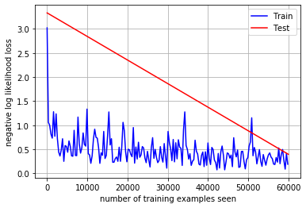

[figure not shown]

[figure not shown]

```python
def main():
    use_cuda = torch.cuda.is_available()
    device = torch.device("cuda" if use_cuda else "cpu")

# data transformation
    train_data = datasets.FashionMNIST('../data', train=True, download=True,
                   transform=transforms.Compose([
                       transforms.ToTensor(),
                   ]))
    test_data = datasets.FashionMNIST('../data', train=False,
                   transform=transforms.Compose([
                       transforms.ToTensor(),
                   ]))
    # data loaders for normalization
    kwargs = {'num_workers': 1, 'pin_memory': True} if use_cuda else {}
    train_loader = torch.utils.data.DataLoader(train_data, batch_size=batch_size, shuffle=True, **kwargs)
    test_loader = torch.utils.data.DataLoader(test_data, batch_size=batch_size, shuffle=False, **kwargs)

    # Getting mean and stddev
    train_mean, train_stddev = mean_std_func(train_loader)

    # Re-loading numerical data, normalized
    train_data = datasets.FashionMNIST('../data', train=True, download=True,
                   transform=transforms.Compose([
                       transforms.ToTensor(),
                       transforms.Normalize((train_mean,), (train_stddev,))
                   ]))
    test_data = datasets.FashionMNIST('../data', train=False,
                   transform=transforms.Compose([
                       transforms.ToTensor(),
                       transforms.Normalize((train_mean,), (train_stddev,))
                   ]))
    # data loaders for normalization
    train_loader = torch.utils.data.DataLoader(train_data, batch_size=batch_size, shuffle=True, **kwargs)
    test_loader = torch.utils.data.DataLoader(test_data, batch_size=batch_size, shuffle=False, **kwargs)

	# extract and plot random samples of data
    #examples = enumerate(test_loader)
    #batch_idx, (data, target) = next(examples)
    #plot_data(data, target, 'Ground truth')

    # model creation
    model = CNN2().to(device)
    # optimizer creation
    optimizer = optim.SGD(model.parameters(), lr=learning_rate, momentum=momentum, weight_decay=weight_decay)


    # lists for saving history
    train_losses = []
    train_counter = []
    test_losses = []
    test_counter = [i*len(train_loader.dataset) for i in range(epochs + 1)]
    train_errors = []
    test_errors = []
    error_counter = [i*len(train_loader.dataset) for i in range(epochs)]

    # test of randomly initialized model
    test(model, device, test_loader, losses=test_losses)

    # global training and testing loop
    for epoch in range(1, epochs + 1):
        train(model, device, train_loader, optimizer, epoch, losses=train_losses, counter=train_counter, errors=train_errors)
        test(model, device, test_loader, losses=test_losses, errors=test_errors)

    # plotting training history
    plot_graph(train_counter, train_losses, test_counter, test_losses, ylabel='negative log likelihood loss')
    plot_graph(error_counter, train_errors, error_counter, test_errors, ylabel='error (%)')

    # extract and plot random samples of data with predicted labels
    data, _, pred = predict_batch(model, device, test_loader)
    plot_data(data, pred, 'Predicted')

if __name__ == '__main__':
    main()
    epochs = 5
```

D- Design CNN3 with additional regularization of your choosing. Explain benefits of such regularization and report its accurracy on fashion MNIST and its relative improvement over CNN2.

> Fasion MNIST with custom CNN architectre with additional regularization of my choice, called using `CNN3()` function.

> Benefits of my `CNN3` architecture.

`AdaGrad` was used as an optimzer. This is a type of adaptive gradient which allows the learning rate to adapt based on parameters.

We see the combination of these changes provide a better result.

CNN2: Accuracy: 8526/10000 (85%) and Average loss: 0.3957 CNN3: Accuracy: 9036/10000 (90%) and Average loss: 0.2746

```
Test set: Average loss: 3.0848, Accuracy: 1513/10000 (15%)

Train Epoch: 1 [0/60000 (0%)]	Loss: 2.646811
Train Epoch: 1 [320/60000 (1%)]	Loss: 0.866260
Train Epoch: 1 [640/60000 (1%)]	Loss: 0.553507
Train Epoch: 1 [960/60000 (2%)]	Loss: 0.722200
Train Epoch: 1 [1280/60000 (2%)]	Loss: 0.693925
Train Epoch: 1 [1600/60000 (3%)]	Loss: 0.737392
Train Epoch: 1 [1920/60000 (3%)]	Loss: 0.654723
Train Epoch: 1 [2240/60000 (4%)]	Loss: 0.682785
Train Epoch: 1 [2560/60000 (4%)]	Loss: 1.023226
Train Epoch: 1 [2880/60000 (5%)]	Loss: 0.697306
Train Epoch: 1 [3200/60000 (5%)]	Loss: 0.689139
Train Epoch: 1 [3520/60000 (6%)]	Loss: 0.636391
Train Epoch: 1 [3840/60000 (6%)]	Loss: 0.870976
Train Epoch: 1 [4160/60000 (7%)]	Loss: 0.761538
Train Epoch: 1 [4480/60000 (7%)]	Loss: 0.235133
Train Epoch: 1 [4800/60000 (8%)]	Loss: 0.628602
Train Epoch: 1 [5120/60000 (9%)]	Loss: 0.742579
Train Epoch: 1 [5440/60000 (9%)]	Loss: 0.554326
Train Epoch: 1 [5760/60000 (10%)]	Loss: 0.426593
Train Epoch: 1 [6080/60000 (10%)]	Loss: 0.160202
Train Epoch: 1 [6400/60000 (11%)]	Loss: 0.427934
Train Epoch: 1 [6720/60000 (11%)]	Loss: 0.451965
Train Epoch: 1 [7040/60000 (12%)]	Loss: 0.790345
Train Epoch: 1 [7360/60000 (12%)]	Loss: 0.541979
Train Epoch: 1 [7680/60000 (13%)]	Loss: 0.409227
Train Epoch: 1 [8000/60000 (13%)]	Loss: 1.051839
Train Epoch: 1 [8320/60000 (14%)]	Loss: 0.301810
Train Epoch: 1 [8640/60000 (14%)]	Loss: 0.448800
Train Epoch: 1 [8960/60000 (15%)]	Loss: 0.412157
Train Epoch: 1 [9280/60000 (15%)]	Loss: 0.837223
Train Epoch: 1 [9600/60000 (16%)]	Loss: 0.474589
Train Epoch: 1 [9920/60000 (17%)]	Loss: 0.451799
Train Epoch: 1 [10240/60000 (17%)]	Loss: 0.496913
Train Epoch: 1 [10560/60000 (18%)]	Loss: 0.251159
Train Epoch: 1 [10880/60000 (18%)]	Loss: 0.345110
Train Epoch: 1 [11200/60000 (19%)]	Loss: 0.695659
Train Epoch: 1 [11520/60000 (19%)]	Loss: 0.830873
Train Epoch: 1 [11840/60000 (20%)]	Loss: 0.864866
```

[output cut: 901 more lines]

```
Train Epoch: 5 [56000/60000 (93%)]	Loss: 0.174806
Train Epoch: 5 [56320/60000 (94%)]	Loss: 0.216144
Train Epoch: 5 [56640/60000 (94%)]	Loss: 0.238225
Train Epoch: 5 [56960/60000 (95%)]	Loss: 0.239755
Train Epoch: 5 [57280/60000 (95%)]	Loss: 0.122178
Train Epoch: 5 [57600/60000 (96%)]	Loss: 0.387360
Train Epoch: 5 [57920/60000 (97%)]	Loss: 0.085698
Train Epoch: 5 [58240/60000 (97%)]	Loss: 0.416546
Train Epoch: 5 [58560/60000 (98%)]	Loss: 0.078801
Train Epoch: 5 [58880/60000 (98%)]	Loss: 0.222878
Train Epoch: 5 [59200/60000 (99%)]	Loss: 0.277313
Train Epoch: 5 [59520/60000 (99%)]	Loss: 0.101592
Train Epoch: 5 [59840/60000 (100%)]	Loss: 0.027624

Test set: Average loss: 0.2746, Accuracy: 9036/10000 (90%)
```

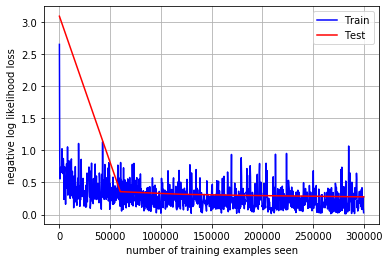

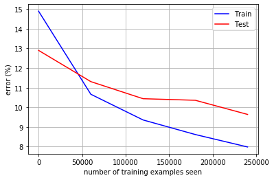

[figure not shown]

```python
def main():
    use_cuda = torch.cuda.is_available()
    device = torch.device("cuda" if use_cuda else "cpu")

# data transformation
    train_data = datasets.FashionMNIST('../data', train=True, download=True,
                   transform=transforms.Compose([
                       transforms.ToTensor(),
                   ]))
    test_data = datasets.FashionMNIST('../data', train=False,
                   transform=transforms.Compose([
                       transforms.ToTensor(),
                   ]))
    # data loaders for normalization
    kwargs = {'num_workers': 1, 'pin_memory': True} if use_cuda else {}
    train_loader = torch.utils.data.DataLoader(train_data, batch_size=batch_size, shuffle=True, **kwargs)
    test_loader = torch.utils.data.DataLoader(test_data, batch_size=batch_size, shuffle=False, **kwargs)

    # Getting mean and stddev
    train_mean, train_stddev = mean_std_func(train_loader)

    # Re-loading numerical data, normalized
    train_data = datasets.FashionMNIST('../data', train=True, download=True,
                   transform=transforms.Compose([
                       transforms.ToTensor(),
                       transforms.Normalize((train_mean,), (train_stddev,))
                   ]))
    test_data = datasets.FashionMNIST('../data', train=False,
                   transform=transforms.Compose([
                       transforms.ToTensor(),
                       transforms.Normalize((train_mean,), (train_stddev,))
                   ]))
    # data loaders for normalization
    train_loader = torch.utils.data.DataLoader(train_data, batch_size=batch_size, shuffle=True, **kwargs)
    test_loader = torch.utils.data.DataLoader(test_data, batch_size=batch_size, shuffle=False, **kwargs)

	# extract and plot random samples of data
    #examples = enumerate(test_loader)
    #batch_idx, (data, target) = next(examples)
    #plot_data(data, target, 'Ground truth')

    # model creation
    model = CNN3().to(device)
    # optimizer creation
    # optimizer = optim.SGD(model.parameters(), lr=learning_rate, momentum=momentum, weight_decay=weight_decay)
    optimizer = optim.Adagrad(model.parameters(), lr=0.01, lr_decay=0, weight_decay=0, initial_accumulator_value=0, eps=1e-10)
    # lists for saving history
    train_losses = []
    train_counter = []
    test_losses = []
    test_counter = [i*len(train_loader.dataset) for i in range(epochs + 1)]
    train_errors = []
    test_errors = []
    error_counter = [i*len(train_loader.dataset) for i in range(epochs)]

    # test of randomly initialized model
    test(model, device, test_loader, losses=test_losses)

    # global training and testing loop
    for epoch in range(1, epochs + 1):
        train(model, device, train_loader, optimizer, epoch, losses=train_losses, counter=train_counter, errors=train_errors)
        test(model, device, test_loader, losses=test_losses, errors=test_errors)

    # plotting training history
    plot_graph(train_counter, train_losses, test_counter, test_losses, ylabel='negative log likelihood loss')
    plot_graph(error_counter, train_errors, error_counter, test_errors, ylabel='error (%)')

    # extract and plot random samples of data with predicted labels
    data, _, pred = predict_batch(model, device, test_loader)
    plot_data(data, pred, 'Predicted')

if __name__ == '__main__':
    main()
```

E- Download file YourEmail_in.csv from the course drive. File contains 5x5 array of integers X. Manually compute valid convolution of w and X and submit output in file named YourEmail_out.csv (note the difference between convolution and cross-correlation, see https://en.wikipedia.org/wiki/Convolution).

```python
incsv=pd.read_csv(incsv_path,header=None)
incsv=np.array(incsv)
w=[[1,0,1],[0,0,0],[-1,0,-1]]
conv_w=np.flipud(np.fliplr(w))
y,x=np.shape(incsv)
m,n=np.shape(conv_w)
final_conv=np.zeros((y-m+1,x-n+1))
### The below three lines perfoms 2D convolution without padding.
for i in range(y-m+1):
  for j in range(x-m+1):
    final_conv[i][j] = np.sum(incsv[i:i+m, j:j+m]*conv_w)
pd.DataFrame(final_conv).to_csv('SIVARAMT@TCD.IE_out.csv',index=False,header=False)
print('Convoluted Output \n')
print(final_conv)
```

```
Convoluted Output

[[ 167.  104.   52.]
 [-122.  -86.  -87.]
 [-169.  -24. -104.]]
```

> Cross correlation generally is sliding a filter/kernel across the image while multiplying and summing, whereas in convolution you slide a flipped filter/kernel across the image while multiplying and summing. This can also be infered from the formula used in calculating both. As in convolution the function takes place over infinity to -infinity (depicted by the negative sign) opposite to that of the image/data, whereas in cross correlation the function takes place over -infinity to infinity (depicted by the positive sign) same that of the image/data.

F- Download file YourEmail_network.csv from the course drive. File contains network definiton in the following format:

i) Convolution, N, K – convolution layer with N feature maps and KxK filters

ii) Maxpool, K – max pooling layer KxK pooling window

iii) Fully-connected, N – fully connected layer with N neurons

All convolutions use same padding that preserves input feature size. All convolutional and fully-connected layers use bias. The network is applied on 32x32 RGB images (3 input channels). Calculate the number of parameters and the number of FLOPS of this network and submit them in YourEmail_params.csv each of the 2 values in separate row (number of parameters in the first row).

```python
network=pd.read_csv(netcsv_path,header=None)
print(network)

inp=3
conv1_out=network[1][0]
conv2_in=conv1_out
conv2_out=network[1][1]
conv3_in=conv2_out
conv3_out=network[1][3]
mp1=network[1][2]
mp2=network[1][4]
fc1_in=conv3_out*(32*32)/(mp1*mp1*mp2*mp2)
fc1_out=network[1][5]
fc2_in=fc1_out
fc2_out=network[1][6]
k1=7
k2=3
k3=3

def conv_param(n,m,k):
  conv=n*m*k*k+m
  return(conv)

def fc_param(n,m):
  fc=n*m+m
  return(fc)

def conv_flops(n,m,k,x):
  conv=n*m*k*k*x*x
  return(conv)

def fc_flops(n,m):
  fc=n*m
  return(fc)

total_param=conv_param(inp,conv1_out,k1)+conv_param(conv2_in,conv2_out,k2)+conv_param(conv3_in,conv3_out,k3)+fc_param(fc1_in,fc1_out)+fc_param(fc2_in,fc2_out)
total_flops=conv_flops(inp,conv1_out,k1,32)+conv_flops(conv2_in,conv2_out,k2,32)+conv_flops(conv3_in,conv3_out,k3,16)+fc_flops(fc1_in,fc1_out)+fc_flops(fc2_in,fc2_out)
print('\nTotal Parameters = %d \nTotal Flops = %d'%(total_param,total_flops))
params=[total_param,total_flops]
pd.DataFrame(params).to_csv('SIVARAMT@TCD.IE_params.csv',index=False,header=False)
```

```
                 0    1    2
0      convolution   12  7.0
1      convolution   40  3.0
2          maxpool    2  NaN
3      convolution   80  3.0
4          maxpool    4  NaN
5  fully-connected  128  NaN
6  fully-connected   10  NaN

Total Parameters = 200274
Total Flops = 13767936
```

## REFERENCES

1. https://machinelearningmastery.com/exploding-gradients-in-neural-networks/
2. https://towardsdatascience.com/the-vanishing-gradient-problem-69bf08b15484
3. https://stats.stackexchange.com/questions/29130/difference-between-neural-net-weight-decay-and-learning-rate
4. https://towardsdatascience.com/the-vanishing-gradient-problem-69bf08b15484
5. https://machinelearningmastery.com/exploding-gradients-in-neural-networks/